# Baseline model with Tidymodels

슬기로운통계생활

4/6/2021

# 슬기로운 통계생활 at DACON!

안녕하세요~! 요즘 핫한 Tidymodels를 사용해서 월간 데이콘 14 - 신용카드 사용자 연체 예측 AI 경진대회 베이스라인을 잡아보자. 😎

# 준비작업

## 패키지 불러오기

```r
suppressMessages(library(tidymodels))
suppressMessages(library(tidyverse))
suppressMessages(library(magrittr))
suppressMessages(library(skimr))
suppressMessages(library(knitr))
theme_set(theme_bw())
```

## 데이터셋 불러오기

이 대회에서 주어진 데이터셋을 불러보자. 주어진 파일 리스트는 다음과 같다.

```r
file_path <- "../input/daconcredit14/"
files <- list.files(file_path)
files
```

```
## [1] "sample_submission.csv" "test.csv"              "train.csv"
```

각 변수의 이름을 `janitor` 패키지로 말끔하게 바꿔준다.

```r
train <- read_csv(file.path(file_path, "train.csv")) %T>%
  suppressMessages() %>%
  janitor::clean_names()
test <- read_csv(file.path(file_path, "test.csv")) %T>%
  suppressMessages() %>%
  janitor::clean_names()
```

# 데이터 기본정보 확인

```r
train %>%
  head() %>%
  kable() %>%
  kableExtra::kable_styling("striped") %>%
  kableExtra::scroll_box(width = "100%")
```

| index | gender | car | reality | child_num | income_total | income_type | edu_type | family_type | house_type | days_birth | days_employed | flag_mobil | work_phone | phone | email | occyp_type | family_size | begin_month | credit |
| --- | --- | --- | --- | --- | --- | --- | --- | --- | --- | --- | --- | --- | --- | --- | --- | --- | --- | --- | --- |
| 0 | F | N | N | 0 | 202500 | Commercial associate | Higher education | Married | Municipal apartment | -13899 | -4709 | 1 | 0 | 0 | 0 | NA | 2 | -6 | 1 |
| 1 | F | N | Y | 1 | 247500 | Commercial associate | Secondary / secondary special | Civil marriage | House / apartment | -11380 | -1540 | 1 | 0 | 0 | 1 | Laborers | 3 | -5 | 1 |
| 2 | M | Y | Y | 0 | 450000 | Working | Higher education | Married | House / apartment | -19087 | -4434 | 1 | 0 | 1 | 0 | Managers | 2 | -22 | 2 |
| 3 | F | N | Y | 0 | 202500 | Commercial associate | Secondary / secondary special | Married | House / apartment | -15088 | -2092 | 1 | 0 | 1 | 0 | Sales staff | 2 | -37 | 0 |
| 4 | F | Y | Y | 0 | 157500 | State servant | Higher education | Married | House / apartment | -15037 | -2105 | 1 | 0 | 0 | 0 | Managers | 2 | -26 | 2 |
| 5 | F | N | Y | 2 | 270000 | Working | Secondary / secondary special | Married | House / apartment | -13413 | -4996 | 1 | 0 | 0 | 1 | High skill tech staff | 4 | -18 | 1 |

## 기본 정보

이 대회는 기본적으로 간단한 대회이다. 첫번째 스터디용 대회로 선택을 한 이유이기도 하다. 주 데이터는 2만 6천개의 train 표본과 1만개의 test 표본들로 구성이 되어있다.

```r
dim(train)
```

```
## [1] 26457    20
```

```r
dim(test)
```

```
## [1] 10000    19
```

각 데이터 셋의 변수명을 살펴보자.

```r
names(train)
```

```
##  [1] "index"         "gender"        "car"           "reality"
##  [5] "child_num"     "income_total"  "income_type"   "edu_type"
##  [9] "family_type"   "house_type"    "days_birth"    "days_employed"
## [13] "flag_mobil"    "work_phone"    "phone"         "email"
## [17] "occyp_type"    "family_size"   "begin_month"   "credit"
```

```r
names(test)
```

```
##  [1] "index"         "gender"        "car"           "reality"
##  [5] "child_num"     "income_total"  "income_type"   "edu_type"
##  [9] "family_type"   "house_type"    "days_birth"    "days_employed"
## [13] "flag_mobil"    "work_phone"    "phone"         "email"
## [17] "occyp_type"    "family_size"   "begin_month"
```

먼저 `test` 데이터에는 우리가 예측하고 싶은 변수인 `credit` 변수가 들어있지 않은 것을 알 수 있다.

데이터를 훑어보기 위해서 `skim()` 함수를 이용하자. 이 함수는 데이터에 들어있는 변수들을 타입 별로 분석해서 리포트를 작성해준다.

```r
skim(train)
```

Data summary

| Name | train |
| --- | --- |
| Number of rows | 26457 |
| Number of columns | 20 |
| _______________________ |  |
| Column type frequency: |  |
| character | 8 |
| numeric | 12 |
| ________________________ |  |
| Group variables | None |

**Variable type: character**

| skim_variable | n_missing | complete_rate | min | max | empty | n_unique | whitespace |
| --- | --- | --- | --- | --- | --- | --- | --- |
| gender | 0 | 1.00 | 1 | 1 | 0 | 2 | 0 |
| car | 0 | 1.00 | 1 | 1 | 0 | 2 | 0 |
| reality | 0 | 1.00 | 1 | 1 | 0 | 2 | 0 |
| income_type | 0 | 1.00 | 7 | 20 | 0 | 5 | 0 |
| edu_type | 0 | 1.00 | 15 | 29 | 0 | 5 | 0 |
| family_type | 0 | 1.00 | 5 | 20 | 0 | 5 | 0 |
| house_type | 0 | 1.00 | 12 | 19 | 0 | 6 | 0 |
| occyp_type | 8171 | 0.69 | 7 | 21 | 0 | 18 | 0 |

**Variable type: numeric**

| skim_variable | n_missing | complete_rate | mean | sd | p0 | p25 | p50 | p75 | p100 | hist |
| --- | --- | --- | --- | --- | --- | --- | --- | --- | --- | --- |
| index | 0 | 1 | 13228.00 | 7637.62 | 0 | 6614 | 13228 | 19842 | 26456 | ▇▇▇▇▇ |
| child_num | 0 | 1 | 0.43 | 0.75 | 0 | 0 | 0 | 1 | 19 | ▇▁▁▁▁ |
| income_total | 0 | 1 | 187306.52 | 101878.37 | 27000 | 121500 | 157500 | 225000 | 1575000 | ▇▁▁▁▁ |
| days_birth | 0 | 1 | -15958.05 | 4201.59 | -25152 | -19431 | -15547 | -12446 | -7705 | ▃▆▇▇▅ |
| days_employed | 0 | 1 | 59068.75 | 137475.43 | -15713 | -3153 | -1539 | -407 | 365243 | ▇▁▁▁▂ |
| flag_mobil | 0 | 1 | 1.00 | 0.00 | 1 | 1 | 1 | 1 | 1 | ▁▁▇▁▁ |
| work_phone | 0 | 1 | 0.22 | 0.42 | 0 | 0 | 0 | 0 | 1 | ▇▁▁▁▂ |
| phone | 0 | 1 | 0.29 | 0.46 | 0 | 0 | 0 | 1 | 1 | ▇▁▁▁▃ |
| email | 0 | 1 | 0.09 | 0.29 | 0 | 0 | 0 | 0 | 1 | ▇▁▁▁▁ |
| family_size | 0 | 1 | 2.20 | 0.92 | 1 | 2 | 2 | 3 | 20 | ▇▁▁▁▁ |
| begin_month | 0 | 1 | -26.12 | 16.56 | -60 | -39 | -24 | -12 | 0 | ▅▆▆▇▇ |
| credit | 0 | 1 | 1.52 | 0.70 | 0 | 1 | 2 | 2 | 2 | ▂▁▃▁▇ |

결과를 살펴보자. 먼저 결측치가 상대적으로 많이 없는 착한? 데이터이다. character 변수의 complete rate를 살펴보면 모든 변수가 1이고, `occyp_type` 변수만이 결측치가 8171개가 존재하는 것을 알 수 있다. 또한 고맙게도 numeric 변수의 결측치는 하나도 없다!😆

같은 함수를 사용해서 `test` 셋을 보면 똑같은 패턴을 가지고 있는 것을 알 수 있다.

```r
skim(test)
```

Data summary

| Name | test |
| --- | --- |
| Number of rows | 10000 |
| Number of columns | 19 |
| _______________________ |  |
| Column type frequency: |  |
| character | 8 |
| numeric | 11 |
| ________________________ |  |
| Group variables | None |

**Variable type: character**

| skim_variable | n_missing | complete_rate | min | max | empty | n_unique | whitespace |
| --- | --- | --- | --- | --- | --- | --- | --- |
| gender | 0 | 1.00 | 1 | 1 | 0 | 2 | 0 |
| car | 0 | 1.00 | 1 | 1 | 0 | 2 | 0 |
| reality | 0 | 1.00 | 1 | 1 | 0 | 2 | 0 |
| income_type | 0 | 1.00 | 7 | 20 | 0 | 5 | 0 |
| edu_type | 0 | 1.00 | 15 | 29 | 0 | 5 | 0 |
| family_type | 0 | 1.00 | 5 | 20 | 0 | 5 | 0 |
| house_type | 0 | 1.00 | 12 | 19 | 0 | 6 | 0 |
| occyp_type | 3152 | 0.68 | 7 | 21 | 0 | 18 | 0 |

**Variable type: numeric**

| skim_variable | n_missing | complete_rate | mean | sd | p0 | p25 | p50 | p75 | p100 | hist |
| --- | --- | --- | --- | --- | --- | --- | --- | --- | --- | --- |
| index | 0 | 1 | 31456.50 | 2886.90 | 26457 | 28956.75 | 31456.5 | 33956.25 | 36456 | ▇▇▇▇▇ |
| child_num | 0 | 1 | 0.43 | 0.73 | 0 | 0.00 | 0.0 | 1.00 | 5 | ▇▁▁▁▁ |
| income_total | 0 | 1 | 185043.32 | 101539.79 | 27000 | 121500.00 | 157500.0 | 225000.00 | 1575000 | ▇▁▁▁▁ |
| days_birth | 0 | 1 | -16020.47 | 4197.67 | -25152 | -19483.25 | -15606.0 | -12539.00 | -7489 | ▃▆▇▇▃ |
| days_employed | 0 | 1 | 59776.69 | 138121.22 | -15661 | -3153.00 | -1577.0 | -410.00 | 365243 | ▇▁▁▁▂ |
| flag_mobil | 0 | 1 | 1.00 | 0.00 | 1 | 1.00 | 1.0 | 1.00 | 1 | ▁▁▇▁▁ |
| work_phone | 0 | 1 | 0.23 | 0.42 | 0 | 0.00 | 0.0 | 0.00 | 1 | ▇▁▁▁▂ |
| phone | 0 | 1 | 0.30 | 0.46 | 0 | 0.00 | 0.0 | 1.00 | 1 | ▇▁▁▁▃ |
| email | 0 | 1 | 0.09 | 0.28 | 0 | 0.00 | 0.0 | 0.00 | 1 | ▇▁▁▁▁ |
| family_size | 0 | 1 | 2.20 | 0.90 | 1 | 2.00 | 2.0 | 3.00 | 7 | ▇▂▁▁▁ |
| begin_month | 0 | 1 | -26.27 | 16.35 | -60 | -39.00 | -25.0 | -12.00 | 0 | ▅▆▇▇▇ |

# 시각화

베이스 라인을 잡은 문서이니 간단하게 시각화 하나만 하고 넘어가자. (코드를 응용해서 다른 변수에 대한 상관 관계를 볼 수 있을 것이다.)

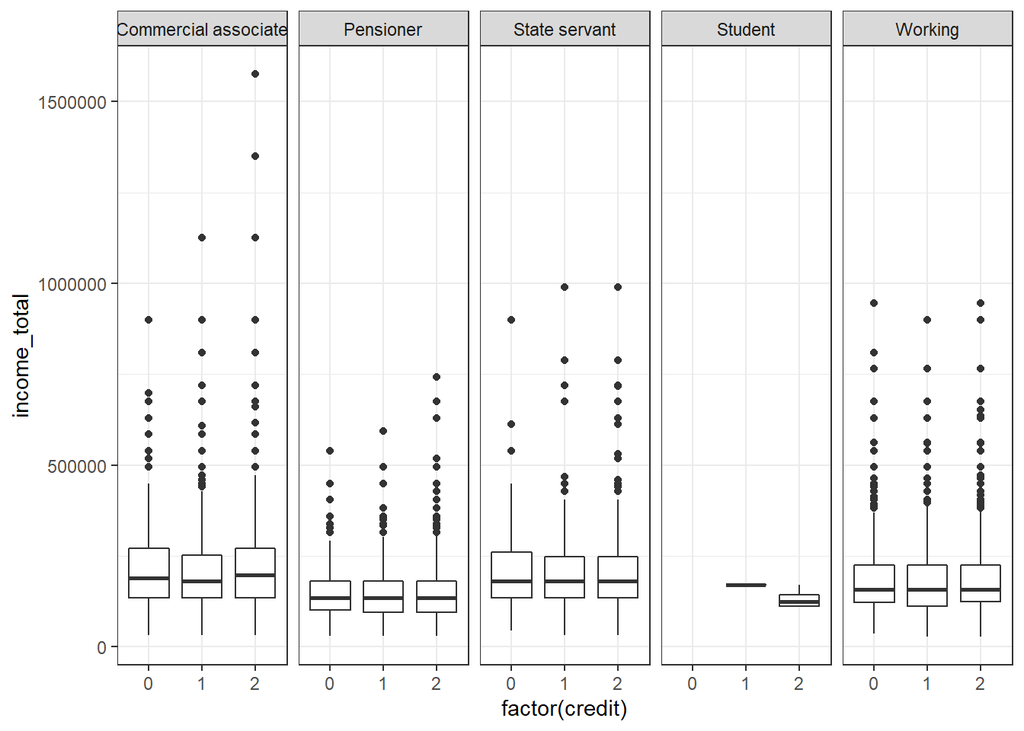

```r
train %>%
  ggplot(aes(x = factor(credit), y = income_total)) +
  geom_boxplot() +
  facet_grid(. ~ income_type)
```

목표 변수인 credit이 Commercial associate 인 경우 수입이 증가할 수록 2번째 클래스에 속하는 것을 볼 때, 0에서 2로 옮겨갈 수 록 신용도가 높은 클래스라는 것을 예측해 볼 수 있다.

학생 클래스의 경우 train 데이터에 셋이 많이 없다는 것을 알 수 있다. 추후에 다른 클래스로 통합을 시키는 것이 좋을 것이다.

## 상관관계

신용 등급 숫자가 높을 경우 신용이 더 좋아진다는 앞에서의 가정하에 상관계수를 구해보면 다음과 같다.

```r
options(max.print = 50)
train %>%
  select_if(is.numeric) %>%
  drop_na() %>%
  cor() %>% as.data.frame() %>%
  rownames_to_column(var = "variables") %>%
  select(variables, credit) %>%
  arrange(desc(abs(credit))) %>% kable()
```

| variables | credit |
| --- | --- |
| credit | 1.0000000 |
| begin_month | -0.1474770 |
| days_birth | -0.0251867 |
| email | 0.0148122 |
| income_total | 0.0085549 |
| family_size | 0.0082274 |
| index | -0.0078407 |
| child_num | 0.0040813 |
| days_employed | -0.0037978 |
| phone | 0.0034517 |
| work_phone | -0.0031338 |
| flag_mobil | NA |

생각보다 크게 나오지는 않지만, 그래도 가입기간과 나이가 신용도에 영향을 미치는 것 같다고 생각된다. 다만, 두 변수와 신용도의 관계를 양의 상관관계로 바꾸기 위해서 전처리 과정에서 부호를 없애주었다.

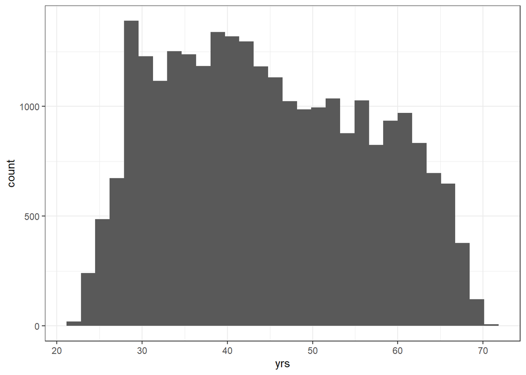

```r
train %>% ggplot(aes(x = -(days_birth/356))) +
  geom_histogram() +
  labs(x = "yrs")
```